# User_analysis

qingye

# 本报告对2017-10-27用户至2017-11-09这两周的行为进行了分析

#### 包括反映用户数目的UV,反映用户活跃度的：人均PV,用户活跃时长,以及反映用户黏度的次日留存，本次报告加入了路径深度的分析,加入了转化部分,并采用多种方式作图

#### 本次报告用R语言自动化生成报告的框架搭建，今后将在此基础上不断改进优化，下次报告将深化转化方面的分析(加入渠道分析)，加深对于路径方面的分析，引进智能化的异常值提醒和分析，考虑加入排名变动

## 近两周的日活跃度(UV)

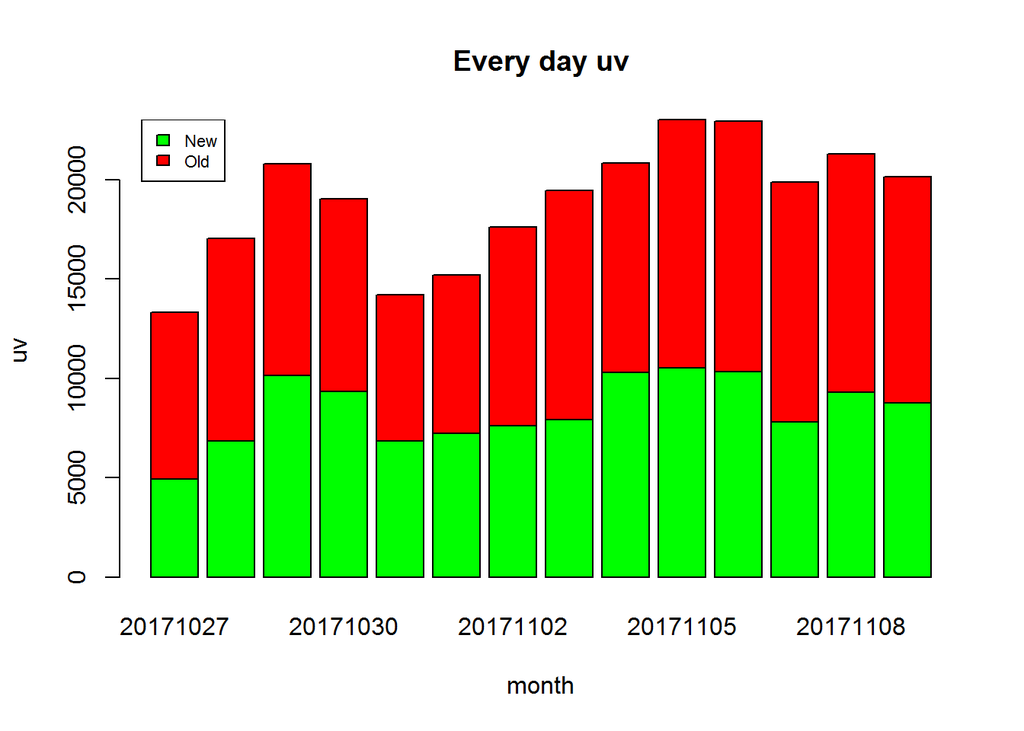

平均UV为18921,

最大UV为23035,

最大值发生在20171105

有0 天新用户在UV值上超过老用户

并没有哪天 用户UV明显高于平均值 并没有哪天 用户UV明显低于平均值

## 近两周人均PV

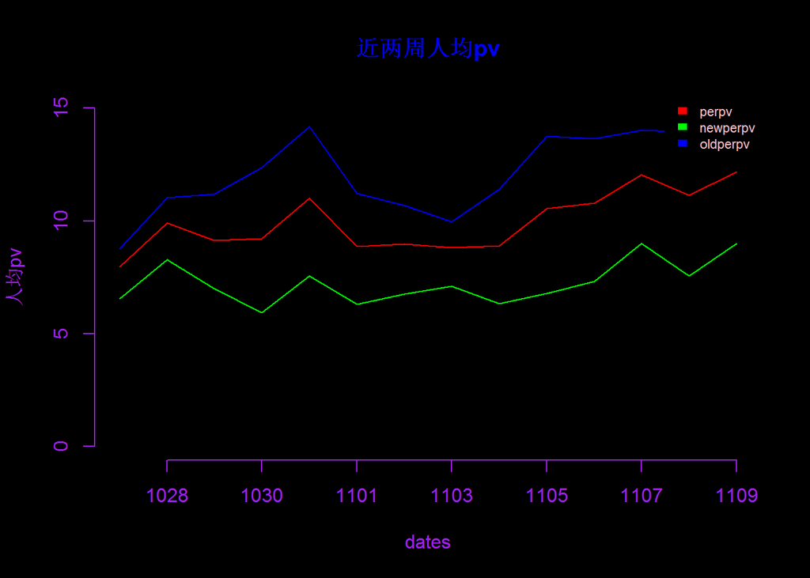

总体PV均值为9.9656187

总体PV最大值为12.1741609 最大值发生在 20171109

总体PV最小值为7.952845 最小值发生在 20171027

新用户PV均值为7.2496911

新用户PV最大值为9.0110832 最大值发生在 20171109

新用户PV最小值为5.9232419 最小值发生在 20171030

老用户PV均值为12.1951537

老用户PV最小值为8.774616 最小值发生在 20171027

有0 天新用户在人均PV值上超过老用户

20171029, 20171030, 20171102, 20171103, 20171104, 20171106 新用户和老用户的趋势不一样

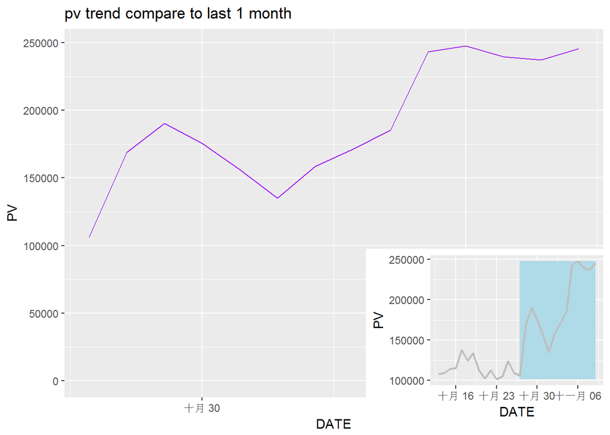

## 用户活跃时长

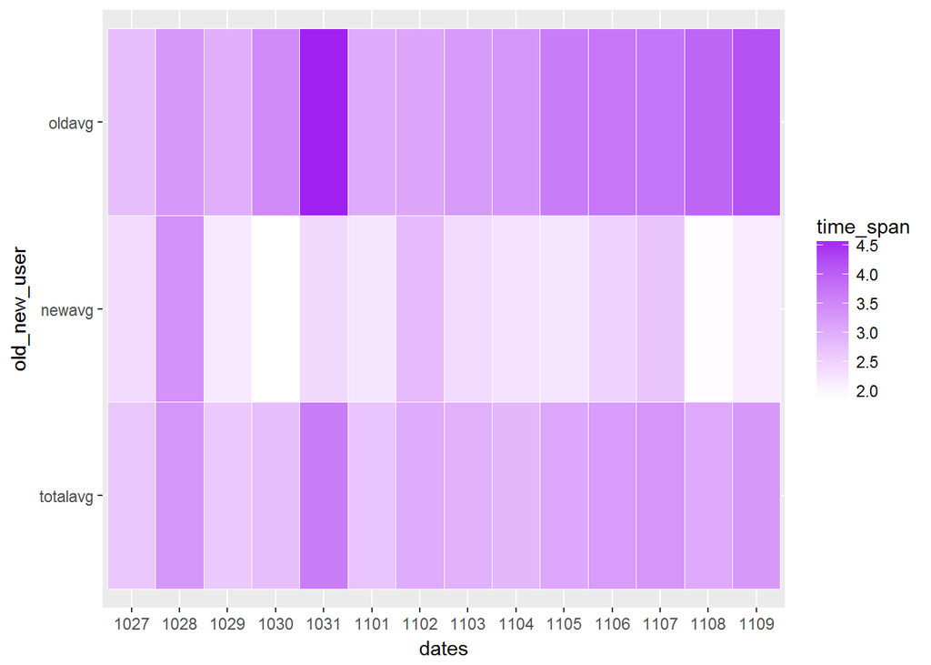

对于用户访问时长作的热力图，可以看出新老用户差距明显，新用户大部分日子访问时长接近白色，可能是今后的努力方向，不过值得留意的是，10/28日，新用户访问时间有了明显提升，可能有什么特别吸引他们的内容，值得研究

## 次日留存

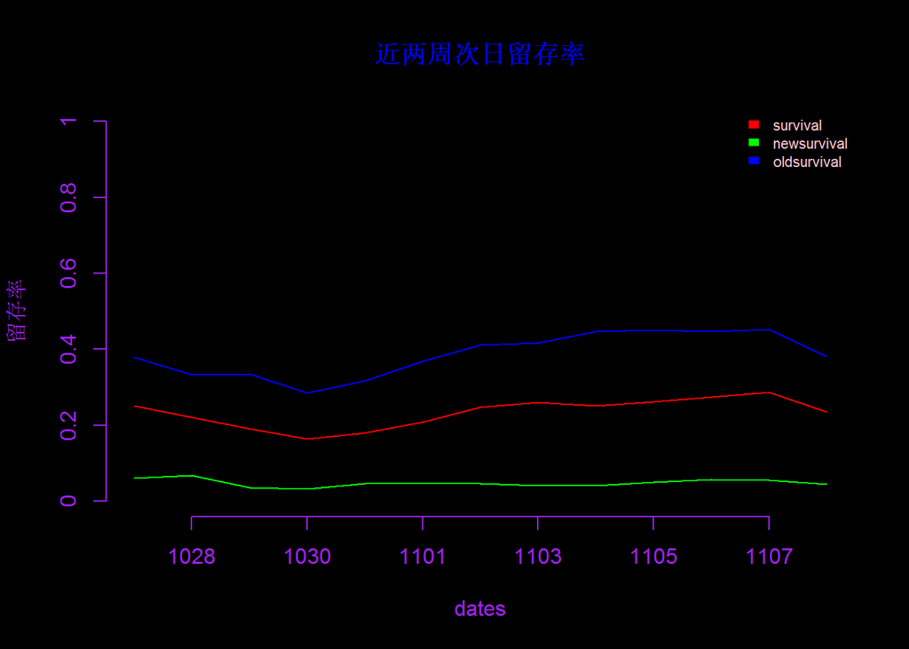

次日留存率，新用户并没有明显的波动，几乎保持水平，整体的波动几乎全部来源于老用户，老用户波动也很小，11月8日留存率有个小小的下降趋势

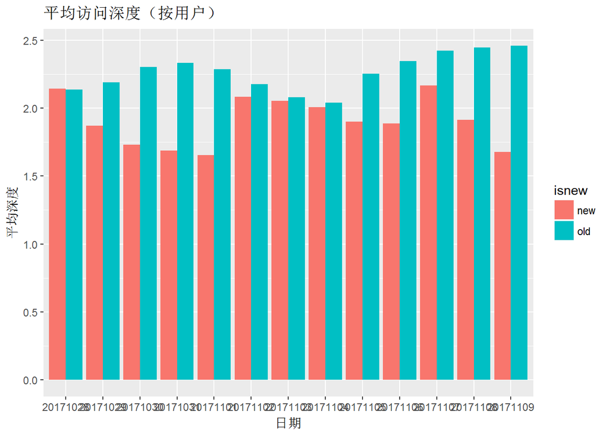

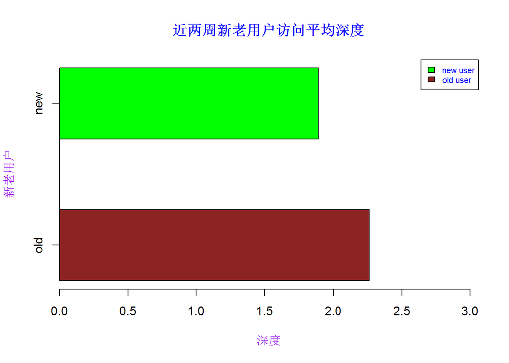

总体来看，新老用户访问深度差异明显

## 新用户不同机型分布

|  | sym | model | 2017-10-27 | 2017-10-28 | 2017-10-29 | 2017-10-30 | 2017-10-31 | 2017-11-01 | 2017-11-02 | 2017-11-03 | 2017-11-04 | 2017-11-05 | 2017-11-06 | 2017-11-07 | 2017-11-08 | 2017-11-09 | sum | rank |
| --- | --- | --- | --- | --- | --- | --- | --- | --- | --- | --- | --- | --- | --- | --- | --- | --- | --- | --- |
| 1 | 789▲ | iPhone 5c | 3 |  | 1619 | 1704 | 319 | 291 | 67 | 70 | 77 | 480 | 568 | 54 | 336 | 1885 | 7473 | 1 |
| 2 | -1▼ | iPhone | 453 | 575 | 653 | 653 | 397 | 496 | 591 | 499 | 770 | 484 | 3 |  |  |  | 5574 | 2 |
| 3 | 5▲ | iPhone 6 | 149 | 213 | 542 | 583 | 354 | 297 | 191 | 244 | 306 | 485 | 591 | 296 | 367 | 703 | 5321 | 3 |
| 4 | 321▲ | iPhone 5 | 2 | 7 | 712 | 737 | 393 | 376 | 96 | 127 | 168 | 449 | 661 | 78 | 336 | 977 | 5119 | 4 |
| 5 | 97▲ | iPhone 5s | 27 | 45 | 696 | 697 | 351 | 326 | 103 | 97 | 116 | 495 | 623 | 114 | 347 | 1046 | 5083 | 5 |
| 6 | 6▲ | iPhone 6 Plus | 94 | 157 | 521 | 503 | 310 | 271 | 176 | 199 | 296 | 455 | 511 | 189 | 312 | 639 | 4633 | 6 |
| 7 | NA | MLA-TL10 |  |  |  |  |  |  | 285 | 375 | 490 | 322 | 579 | 374 | 406 | 292 | 3123 | 7 |
| 8 | -6▼ | vivo X9 | 87 | 281 | 220 | 242 | 240 | 181 | 201 | 160 | 171 | 174 | 179 | 169 | 225 | 216 | 2746 | 8 |
| 9 | -2▼ | iPhone 7 Plus | 112 | 161 | 170 | 198 | 157 | 199 | 155 | 178 | 242 | 227 | 227 | 198 | 180 | 215 | 2619 | 9 |
| 10 | -6▼ | Linux armv8l | 144 | 245 | 338 | 206 | 130 | 203 | 353 | 217 | 352 | 178 |  |  |  |  | 2366 | 10 |

[output cut: 90 more lines]

本周加入排名相对前两周的变化，通过排名巨大变化可看出iphone5,iphone5c 有刷单嫌疑

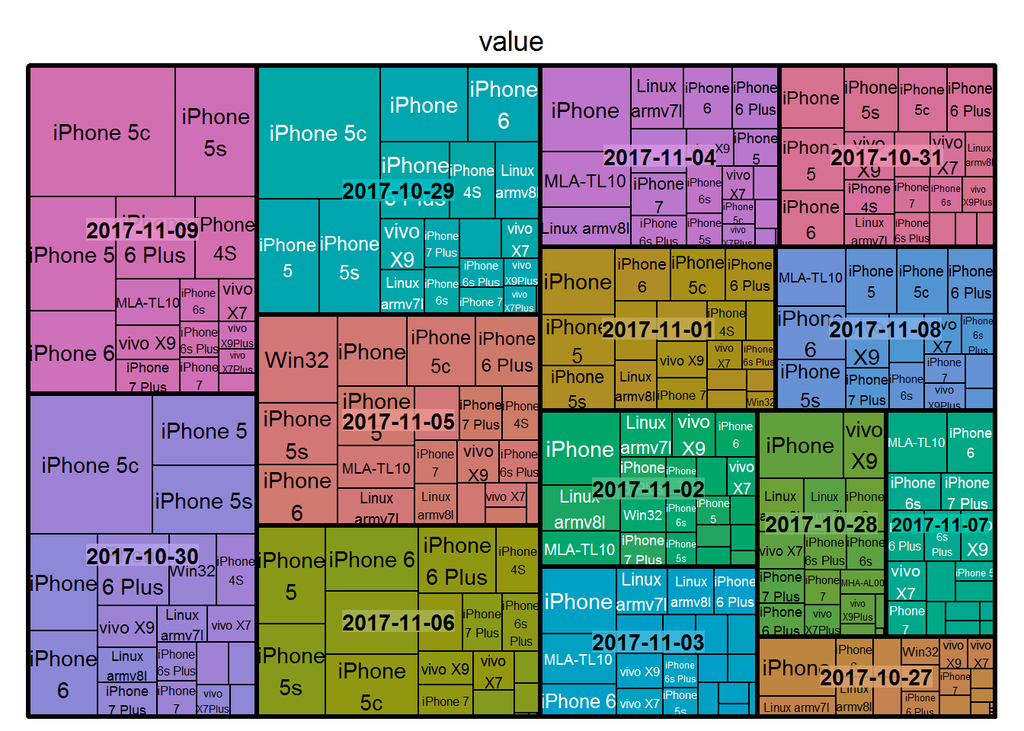

结构矩形树图，大矩形为日期，小矩形为具体机型，按从大到小的顺序，从上到下，从左到右排列

## 新用户不同城市分布

|  | sym | city | 2017-10-27 | 2017-10-28 | 2017-10-29 | 2017-10-30 | 2017-10-31 | 2017-11-01 | 2017-11-02 | 2017-11-03 | 2017-11-04 | 2017-11-05 | 2017-11-06 | 2017-11-07 | 2017-11-08 | 2017-11-09 | sum | rank |
| --- | --- | --- | --- | --- | --- | --- | --- | --- | --- | --- | --- | --- | --- | --- | --- | --- | --- | --- |
| 60 | 0 | 上海 | 1336 | 1940 | 2612 | 2081 | 1222 | 1563 | 2406 | 2163 | 2826 | 2329 | 811 | 850 | 824 | 829 | 22968 | 1 |
| 67 | 2▲ | 苏州 | 502 | 954 | 995 | 1309 | 1072 | 1051 | 1232 | 1181 | 1556 | 680 | 886 | 717 | 717 | 816 | 12951 | 2 |
| 57 | 53▲ | 泉州 | 15 | 19 | 23 | 19 | 25 | 28 | 60 | 578 | 1665 | 1743 | 1629 | 3142 | 2984 | 348 | 9294 | 3 |
| 4 | -2▼ | 北京 | 417 | 643 | 674 | 576 | 489 | 398 | 897 | 636 | 510 | 778 | 453 | 367 | 414 | 440 | 7278 | 4 |
| 51 | -2▼ | 南京 | 434 | 744 | 917 | 412 | 389 | 333 | 451 | 399 | 606 | 1097 | 488 | 333 | 279 | 264 | 6867 | 5 |
| 63 | 8▲ | 沈阳 | 77 | 90 | 1321 | 1308 | 65 | 84 | 88 | 76 | 67 | 589 | 708 | 66 | 60 | 1147 | 5686 | 6 |
| 56 | 175▲ | 清远 | 8 | 4 | 1005 | 1003 | 2 | 3 | 5 | 3 |  | 355 | 653 | 4 | 4 | 965 | 4010 | 7 |
| 25 | -3▼ | 合肥 | 125 | 155 | 181 | 172 | 111 | 116 | 219 | 209 | 261 | 223 | 364 | 265 | 141 | 176 | 2577 | 8 |
| 89 | 18▲ | 扬州 | 63 | 57 | 39 | 124 | 51 | 269 | 140 | 131 | 110 | 289 | 257 | 151 | 209 | 126 | 1807 | 9 |
| 77 | 0 | 无锡 | 113 | 95 | 95 | 101 | 117 | 174 | 129 | 73 | 120 | 219 | 203 | 125 | 125 | 78 | 1642 | 10 |

[output cut: 91 more lines]

上海作为新用户产生城市几乎是第二名贡献的2倍，可能有一定问题，京沪地区，长三角，仍然是最显著区域，东北地区沈阳的排名比上次有所提高，西北和中部地区仍然偏少，华南地区排名有所下降，成渝地区有所下降，清远和泉州有巨大提高，要么有活动，要么是刷单嫌疑

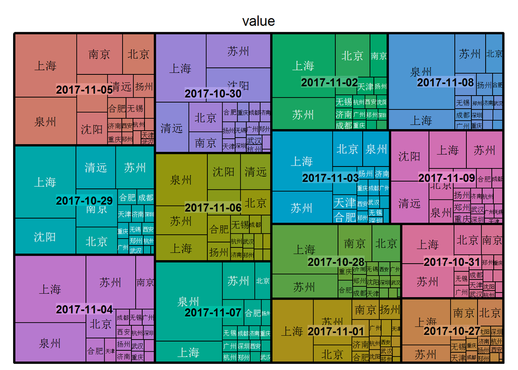

结构矩形树图，大矩形为日期，小矩形为具体城市，按从大到小的顺序，从上到下，从左到右排列

## 新用户不同渠道分布

|  | channels | 2017-10-27 | 2017-10-28 | 2017-10-29 | 2017-10-30 | 2017-10-31 | 2017-11-01 | 2017-11-02 | 2017-11-03 | 2017-11-04 | 2017-11-05 | 2017-11-06 | 2017-11-07 | 2017-11-08 | 2017-11-09 | sum |
| --- | --- | --- | --- | --- | --- | --- | --- | --- | --- | --- | --- | --- | --- | --- | --- | --- |
| 1 | 30015 | 1567 | 1990 | 2136 | 1994 | 1227 | 1681 | 2581 | 2311 | 4156 | 4167 | 1375 | 2513 | 2441 | 243 | 30382 |
| 2 | 二维码-Android | 537 | 943 | 1149 | 922 | 664 | 749 | 1194 | 2084 | 2259 | 1374 | 1864 | 1967 | 1984 | 1740 | 19430 |
| 3 | 二维码-IOS | 181 | 396 | 1283 | 621 | 2005 | 1949 | 769 | 885 | 1213 | 1380 | 658 | 748 | 1700 | 2041 | 15829 |
| 4 | Appstore | 302 | 342 | 1852 | 2372 | 313 | 261 | 287 | 303 | 439 | 928 | 1783 | 477 | 606 | 2184 | 12449 |
| 5 | vivo | 197 | 1001 | 901 | 960 | 965 | 629 | 658 | 562 | 548 | 470 | 718 | 664 | 838 | 807 | 9918 |
| 6 | 360手助 | 1058 | 609 | 804 | 868 | 366 | 834 | 770 | 430 | 170 | 974 | 175 | 136 | 334 | 579 | 8107 |
| 7 | 华为 | 72 | 241 | 454 | 345 | 206 | 220 | 226 | 212 | 354 | 323 | 322 | 300 | 245 | 243 | 3763 |
| 8 | 小米 | 16 | 130 | 269 | 214 | 221 | 182 | 172 | 166 | 185 | 203 | 142 | 133 | 141 | 129 | 2303 |
| 9 | 二维码-其他 | 131 | 231 | 100 | 54 | 81 | 49 | 46 | 86 | 65 | 106 | 386 | 228 | 174 | 315 | 2052 |
| 10 | 百度手助 | 120 | 161 | 177 | 136 | 163 | 108 | 71 | 56 | 129 | 223 | 160 | 176 | 145 | 202 | 2027 |

[output cut: 36 more lines]

二维码，30015，appstore,360助手都占据不错份额，360助手平时占比更高

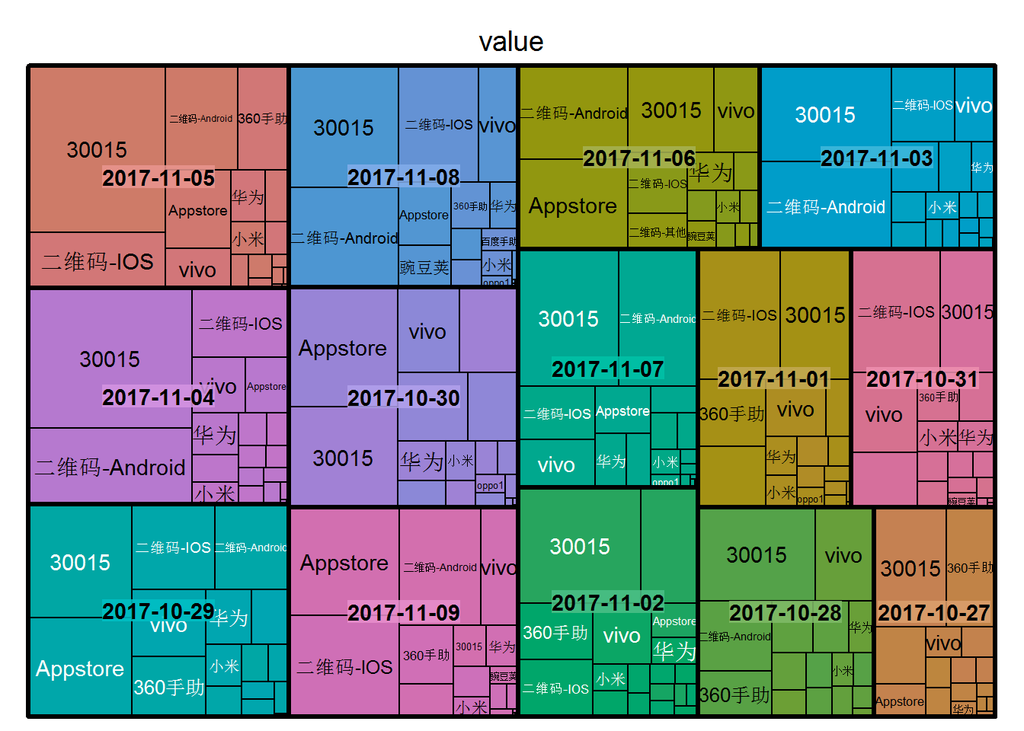

结构矩形树图，大矩形为日期，小矩形为具体渠道，按从大到小的顺序，从上到下，从左到右排列

# 转化问题

## 每日订单数

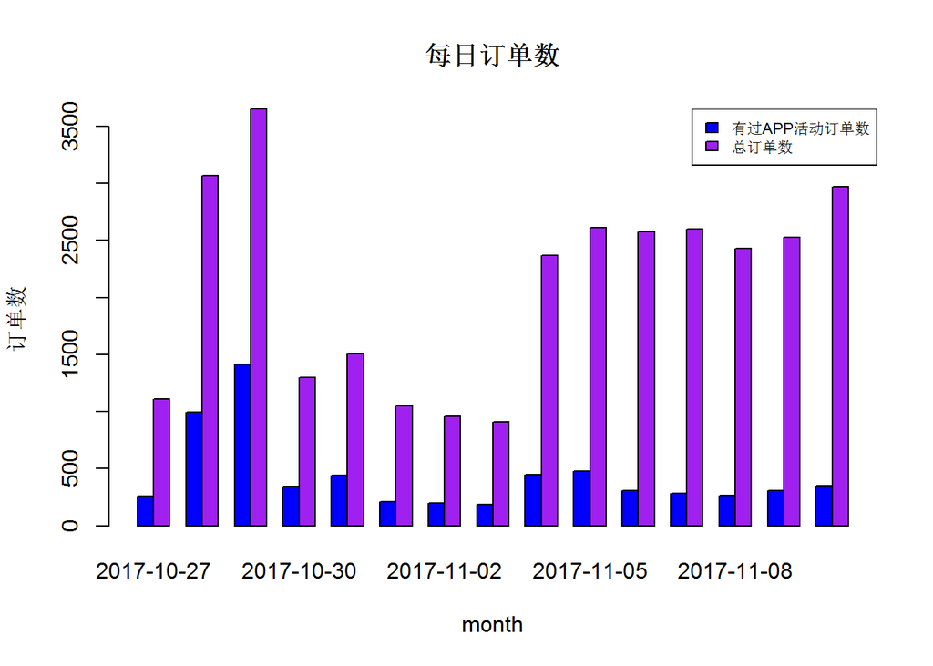

## 房产预约

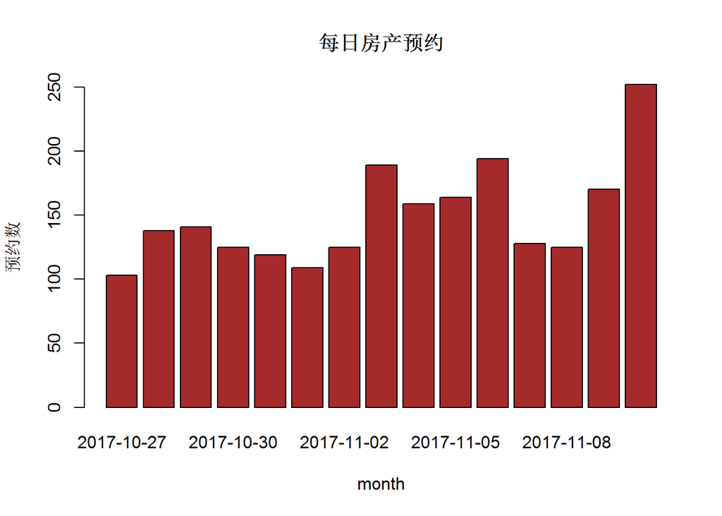

## 领券情况

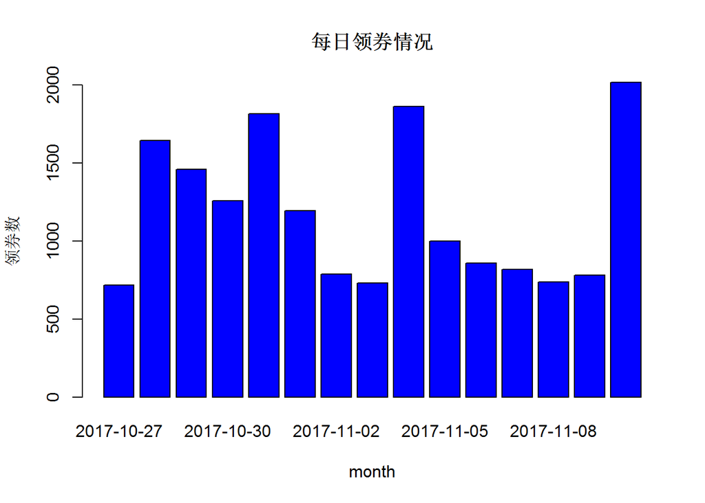